# Finding the Best Two Markets to Advertise In

**What the project is about.**  
An e-learning company offers courses on programming. Most of courses are on web and mobile development, but they also cover many other domains, like data science, game development, etc. Company wants to promote their product and it'd like to invest some money in advertisement.

**What the goal is in this project.**  
The goal in this project is to find out the two best markets to advertise the product in.

```python
import pandas as pd
import numpy as np
import seaborn as sns
%matplotlib inline
import matplotlib.pyplot as plt
plt.style.use('fivethirtyeight')

import warnings
warnings.simplefilter(action='ignore', category=FutureWarning)
```

### Understanding the Data

**Data source:**  
[freeCodeCamp](https://www.freecodecamp.org/) is a free e-learning platform that offers courses on web development.  
Because they run a popular Medium publication, their survey attracted new coders with varying interests (not only web development), which is ideal for the purpose of the analysis.

The survey data is publicly available in [this GitHub repository](https://github.com/freeCodeCamp/2017-new-coder-survey).

```python
pd.set_option('display.max_columns', None)

survey_data = pd.read_csv('2017-fCC-New-Coders-Survey-Data.csv', low_memory = 0)
```

```python
survey_data.shape
```

```
(18175, 136)
```

```python
survey_data.head()
```

|  | Age | AttendedBootcamp | BootcampFinish | BootcampLoanYesNo | BootcampName | BootcampRecommend | ChildrenNumber | CityPopulation | CodeEventConferences | CodeEventDjangoGirls | CodeEventFCC | CodeEventGameJam | CodeEventGirlDev | CodeEventHackathons | CodeEventMeetup | CodeEventNodeSchool | CodeEventNone | CodeEventOther | CodeEventRailsBridge | CodeEventRailsGirls | CodeEventStartUpWknd | CodeEventWkdBootcamps | CodeEventWomenCode | CodeEventWorkshops | CommuteTime | CountryCitizen | CountryLive | EmploymentField | EmploymentFieldOther | … |
| --- | --- | --- | --- | --- | --- | --- | --- | --- | --- | --- | --- | --- | --- | --- | --- | --- | --- | --- | --- | --- | --- | --- | --- | --- | --- | --- | --- | --- | --- | --- |
| 0 | 27.0 | 0.0 | NaN | NaN | NaN | NaN | NaN | more than 1 million | NaN | NaN | NaN | NaN | NaN | NaN | NaN | NaN | NaN | NaN | NaN | NaN | NaN | NaN | NaN | NaN | 15 to 29 minutes | Canada | Canada | software development and IT | NaN | … |
| 1 | 34.0 | 0.0 | NaN | NaN | NaN | NaN | NaN | less than 100,000 | NaN | NaN | NaN | NaN | NaN | NaN | NaN | NaN | NaN | NaN | NaN | NaN | NaN | NaN | NaN | NaN | NaN | United States of America | United States of America | NaN | NaN | … |
| 2 | 21.0 | 0.0 | NaN | NaN | NaN | NaN | NaN | more than 1 million | NaN | NaN | NaN | NaN | NaN | 1.0 | NaN | 1.0 | NaN | NaN | NaN | NaN | NaN | NaN | NaN | NaN | 15 to 29 minutes | United States of America | United States of America | software development and IT | NaN | … |
| 3 | 26.0 | 0.0 | NaN | NaN | NaN | NaN | NaN | between 100,000 and 1 million | NaN | NaN | NaN | NaN | NaN | NaN | NaN | NaN | NaN | NaN | NaN | NaN | NaN | NaN | NaN | NaN | I work from home | Brazil | Brazil | software development and IT | NaN | … |
| 4 | 20.0 | 0.0 | NaN | NaN | NaN | NaN | NaN | between 100,000 and 1 million | NaN | NaN | NaN | NaN | NaN | NaN | NaN | NaN | NaN | NaN | NaN | NaN | NaN | NaN | NaN | NaN | NaN | Portugal | Portugal | NaN | NaN | … |

### Checking for Sample Representativity

For the purpose of the analysis, we want to answer questions about a population of new coders that are interested in the subjects we teach. We'd like to know:

- Where are these new coders located.
- What are the locations with the greatest number of new coders.
- How much money new coders are willing to spend on learning.

```python
frec_survey_data = survey_data['JobRoleInterest'].value_counts().to_frame().reset_index()
frec_survey_data['percentage'] = (frec_survey_data['JobRoleInterest'] / frec_survey_data['JobRoleInterest'].sum())*100
```

```python
frec_survey_data
```

|  | index | JobRoleInterest | percentage |
| --- | --- | --- | --- |
| 0 | Full-Stack Web Developer | 823 | 11.770595 |
| 1 | Front-End Web Developer | 450 | 6.435927 |
| 2 | Data Scientist | 152 | 2.173913 |
| 3 | Back-End Web Developer | 142 | 2.030892 |
| 4 | Mobile Developer | 117 | 1.673341 |
| 5 | Game Developer | 114 | 1.630435 |
| 6 | Information Security | 92 | 1.315789 |
| 7 | Full-Stack Web Developer, Front-End Web Deve... | 64 | 0.915332 |
| 8 | Front-End Web Developer, Full-Stack Web Deve... | 56 | 0.800915 |
| 9 | Product Manager | 55 | 0.786613 |
| 10 | Data Engineer | 53 | 0.758009 |
| 11 | User Experience Designer | 52 | 0.743707 |
| 12 | User Experience Designer, Front-End Web De... | 43 | 0.614989 |
| 13 | Front-End Web Developer, Back-End Web Develo... | 39 | 0.557780 |
| 14 | Back-End Web Developer, Full-Stack Web Develop... | 36 | 0.514874 |
| 15 | DevOps / SysAdmin | 36 | 0.514874 |
| 16 | Back-End Web Developer, Front-End Web Develo... | 36 | 0.514874 |
| 17 | Full-Stack Web Developer, Front-End Web Deve... | 31 | 0.443364 |
| 18 | Front-End Web Developer, Full-Stack Web Deve... | 30 | 0.429062 |
| 19 | Full-Stack Web Developer, Mobile Developer | 29 | 0.414760 |
| 20 | Front-End Web Developer, User Experience D... | 29 | 0.414760 |
| 21 | Back-End Web Developer, Full-Stack Web Developer | 27 | 0.386156 |
| 22 | Full-Stack Web Developer, Back-End Web Developer | 26 | 0.371854 |
| 23 | Back-End Web Developer, Front-End Web Developer | 20 | 0.286041 |
| 24 | Full-Stack Web Developer, Back-End Web Develop... | 19 | 0.271739 |
| 25 | Data Engineer, Data Scientist | 19 | 0.271739 |
| 26 | Front-End Web Developer, Mobile Developer | 18 | 0.257437 |
| 27 | Full-Stack Web Developer, Data Scientist | 17 | 0.243135 |
| 28 | Data Scientist, Data Engineer | 16 | 0.228833 |
| 29 | Mobile Developer, Game Developer | 16 | 0.228833 |
| ... | ... | ... | ... |
| 3183 | Full-Stack Web Developer, Mobile Developer, ... | 1 | 0.014302 |
| 3184 | Front-End Web Developer, Product Manager, ... | 1 | 0.014302 |
| 3185 | Game Developer, User Experience Designer, ... | 1 | 0.014302 |
| 3186 | User Experience Designer, Game Developer, In... | 1 | 0.014302 |
| 3187 | Front-End Web Developer, Information Securit... | 1 | 0.014302 |
| 3188 | Game Developer, Front-End Web Developer, Dat... | 1 | 0.014302 |
| 3189 | Software Developper | 1 | 0.014302 |
| 3190 | Back-End Web Developer, Product Manager, D... | 1 | 0.014302 |
| 3191 | Information Security, Data Scientist, DevO... | 1 | 0.014302 |
| 3192 | Back-End Web Developer, Information Security, ... | 1 | 0.014302 |
| 3193 | User Experience Designer, Product Manager,... | 1 | 0.014302 |
| 3194 | Full-Stack Web Developer, Data Engineer, Fro... | 1 | 0.014302 |
| 3195 | Mobile Developer, User Experience Designer... | 1 | 0.014302 |
| 3196 | User Experience Designer, Data Engineer, Gam... | 1 | 0.014302 |
| 3197 | Information Security, Mobile Developer, De... | 1 | 0.014302 |
| 3198 | Product Manager, Game Developer, Data Engine... | 1 | 0.014302 |
| 3199 | Full-Stack Web Developer, Information Security... | 1 | 0.014302 |
| 3200 | Research | 1 | 0.014302 |
| 3201 | User Experience Designer, Front-End Web De... | 1 | 0.014302 |
| 3202 | Back-End Web Developer, Mobile Developer, Ga... | 1 | 0.014302 |
| 3203 | Back-End Web Developer, Data Engineer, DevOp... | 1 | 0.014302 |
| 3204 | Full-Stack Web Developer, Product Manager, ... | 1 | 0.014302 |
| 3205 | Full-Stack Web Developer, Front-End Web Deve... | 1 | 0.014302 |
| 3206 | Full-Stack Web Developer, Quality Assurance ... | 1 | 0.014302 |
| 3207 | Back-End Web Developer, Game Developer, DevO... | 1 | 0.014302 |
| 3208 | User Experience Designer, Back-End Web Devel... | 1 | 0.014302 |
| 3209 | Full-Stack Web Developer, Front-End Web Deve... | 1 | 0.014302 |
| 3210 | DevOps / SysAdmin, Quality Assurance Engin... | 1 | 0.014302 |
| 3211 | Mobile Developer, Back-End Web Developer, ... | 1 | 0.014302 |
| 3212 | Back-End Web Developer, Quality Assurance En... | 1 | 0.014302 |

3213 rows × 3 columns

The 'JobRoleInterest' column describes for every participant the role(s) they'd be interested in working.

From the frequency distribution table I can say people are interested not only in one subject, but they can be interested in several subjects.

```python
# Split each string in the 'JobRoleInterest' column
interests_no_nulls = survey_data['JobRoleInterest'].dropna()
splitted_interests = interests_no_nulls.str.split(',')

n_of_options = splitted_interests.apply(lambda x: len(x))
n_of_options.value_counts(normalize = True).sort_index() * 100
```

```
1     31.650458
2     10.883867
3     15.889588
4     15.217391
5     12.042334
6      6.721968
7      3.861556
8      1.759153
9      0.986842
10     0.471968
11     0.185927
12     0.300343
13     0.028604
Name: JobRoleInterest, dtype: float64
```

```python
percentage_first = round((n_of_options.value_counts(normalize = True).sort_index() * 100),2)[1]
```

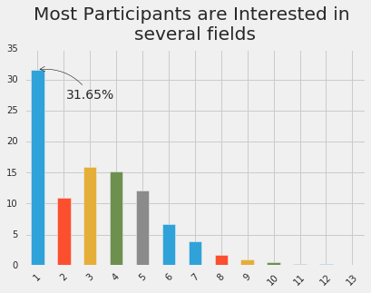

```python
(n_of_options.value_counts(normalize = True).sort_index() * 100).plot.bar(rot=45)
plt.title('Most Participants are Interested in \nseveral fields', y = 1.02)

plt.annotate(str(percentage_first)+'%',xy=(0,percentage_first), xytext=('2',27),
             arrowprops={'arrowstyle':'->', 'connectionstyle':'arc3,rad=0.3', "color":"black"}
             ,horizontalalignment='center')
plt.show()
```

Only 31.65% of people choose one subject, the majory choosing two and more.

```python
web_or_mobile = interests_no_nulls.str.contains(
    'Web Developer|Mobile Developer')
freq_table = web_or_mobile.value_counts(normalize = True) * 100
```

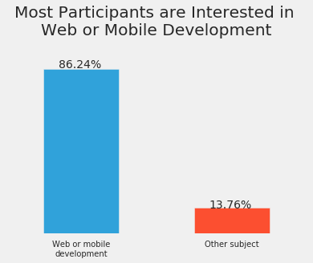

```python
freq_table.plot.bar(rot=45)
plt.title('Most Participants are Interested in \nWeb or Mobile Development',
          y = 1.02)
plt.text(-0.15, 87, str(round(freq_table[1],2))+'%', fontsize=14)
plt.text(0.85, 14, str(round(freq_table[0],2))+'%', fontsize=14)
plt.xticks([0,1],['Web or mobile\ndevelopment', 'Other subject'],
           rotation = 0)
plt.yticks([])
plt.ylim([0,100])
plt. grid(False)
plt.show()
```

As you can see from the bar plot most people in this survey (roughly 86%) are interested in either web or mobile development.  
So, we have a strong reason to consider this sample representative for our population of interest. Company wants to advertise courses to people interested in all sorts of programming niches but mostly web and mobile development.

### New Coders - Locations and Densities

The data set provides information about the location of each participant at a country level. The 'CountryCitizen' variable describes the country of origin for each participant, and the 'CountryLive' variable describes what country each participants lives in (which may be different than the origin country).

As we are interested where people are located, not where they were born, I will use 'CountryLive' column for analysis.

I will think of each country as an individual market. This means I can frame my goal as finding the two best countries to advertise in.

```python
sample = survey_data[survey_data['JobRoleInterest'].notnull()].copy()
```

```python
frec_sample = sample['CountryLive'].value_counts().to_frame().reset_index()
frec_sample['percentage'] = (frec_sample['CountryLive'] / frec_sample['CountryLive'].sum())*100
frec_sample = frec_sample.rename(columns={'index':'CountryName', 'CountryLive':'Count'})
frec_sample
```

|  | CountryName | Count | percentage |
| --- | --- | --- | --- |
| 0 | United States of America | 3125 | 45.700497 |
| 1 | India | 528 | 7.721556 |
| 2 | United Kingdom | 315 | 4.606610 |
| 3 | Canada | 260 | 3.802281 |
| 4 | Poland | 131 | 1.915765 |
| 5 | Brazil | 129 | 1.886517 |
| 6 | Germany | 125 | 1.828020 |
| 7 | Australia | 112 | 1.637906 |
| 8 | Russia | 102 | 1.491664 |
| 9 | Ukraine | 89 | 1.301550 |
| 10 | Nigeria | 84 | 1.228429 |
| 11 | Spain | 77 | 1.126060 |
| 12 | France | 75 | 1.096812 |
| 13 | Romania | 71 | 1.038315 |
| 14 | Netherlands (Holland, Europe) | 65 | 0.950570 |
| 15 | Italy | 62 | 0.906698 |
| 16 | Serbia | 52 | 0.760456 |
| 17 | Philippines | 52 | 0.760456 |
| 18 | Greece | 46 | 0.672711 |
| 19 | Ireland | 43 | 0.628839 |
| 20 | South Africa | 39 | 0.570342 |
| 21 | Mexico | 37 | 0.541094 |
| 22 | Turkey | 36 | 0.526470 |
| 23 | Singapore | 34 | 0.497221 |
| 24 | Hungary | 34 | 0.497221 |
| 25 | New Zealand | 33 | 0.482597 |
| 26 | Croatia | 32 | 0.467973 |
| 27 | Argentina | 32 | 0.467973 |
| 28 | Indonesia | 31 | 0.453349 |
| 29 | Sweden | 31 | 0.453349 |
| ... | ... | ... | ... |
| 107 | Yemen | 1 | 0.014624 |
| 108 | Myanmar | 1 | 0.014624 |
| 109 | Kyrgyzstan | 1 | 0.014624 |
| 110 | Panama | 1 | 0.014624 |
| 111 | Qatar | 1 | 0.014624 |
| 112 | Rwanda | 1 | 0.014624 |
| 113 | Anguilla | 1 | 0.014624 |
| 114 | Trinidad & Tobago | 1 | 0.014624 |
| 115 | Channel Islands | 1 | 0.014624 |
| 116 | Turkmenistan | 1 | 0.014624 |
| 117 | Sudan | 1 | 0.014624 |
| 118 | Samoa | 1 | 0.014624 |
| 119 | Botswana | 1 | 0.014624 |
| 120 | Somalia | 1 | 0.014624 |
| 121 | Mozambique | 1 | 0.014624 |
| 122 | Cuba | 1 | 0.014624 |
| 123 | Papua New Guinea | 1 | 0.014624 |
| 124 | Cameroon | 1 | 0.014624 |
| 125 | Gambia | 1 | 0.014624 |
| 126 | Aruba | 1 | 0.014624 |
| 127 | Gibraltar | 1 | 0.014624 |
| 128 | Nicaragua | 1 | 0.014624 |
| 129 | Liberia | 1 | 0.014624 |
| 130 | Nambia | 1 | 0.014624 |
| 131 | Guadeloupe | 1 | 0.014624 |
| 132 | Bolivia | 1 | 0.014624 |
| 133 | Cayman Islands | 1 | 0.014624 |
| 134 | Vanuatu | 1 | 0.014624 |
| 135 | Jordan | 1 | 0.014624 |
| 136 | Angola | 1 | 0.014624 |

137 rows × 3 columns

```python
frec_sample['percentage'].head(10).sum()
```

```
71.89236618894414
```

```python
frec_sample['CountryName'] = frec_sample['CountryName'].replace('United States of America', 'USA').replace('United Kingdom','UK')
```

```python
top_4_percentages = [round(frec_sample['percentage'][0],2),
                    round(frec_sample['percentage'][1],2),
                    round(frec_sample['percentage'][2],2),
                    round(frec_sample['percentage'][3],2)]
```

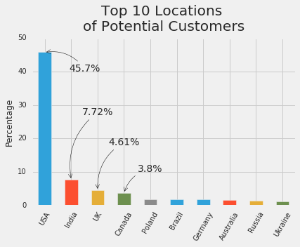

```python
frec_sample['percentage'].head(10).plot.bar(rot=60)
plt.xticks(np.arange(10),list(frec_sample['CountryName'].head(10)))
plt.title('Top 10 Locations \nof Potential Customers', y = 1.02)
plt.ylabel('Percentage', fontsize = 12)

plt.annotate(str(top_4_percentages[0])+'%',xy=(0,top_4_percentages[0]), xytext=('1.5',40),
             arrowprops={'arrowstyle':'->', 'connectionstyle':'arc3,rad=0.3', "color":"black"}
             ,horizontalalignment='center')
plt.annotate(str(top_4_percentages[1])+'%',xy=(1,top_4_percentages[1]), xytext=('2',27),
             arrowprops={'arrowstyle':'->', 'connectionstyle':'arc3,rad=0.3', "color":"black"}
             ,horizontalalignment='center')
plt.annotate(str(top_4_percentages[2])+'%',xy=(2,top_4_percentages[2]), xytext=('3',18),
             arrowprops={'arrowstyle':'->', 'connectionstyle':'arc3,rad=0.3', "color":"black"}
             ,horizontalalignment='center')
plt.annotate(str(top_4_percentages[3])+'%',xy=(3,top_4_percentages[3]), xytext=('4',10),
             arrowprops={'arrowstyle':'->', 'connectionstyle':'arc3,rad=0.3', "color":"black"}
             ,horizontalalignment='center')
plt.show()
```

45.7% of our potential customers are located in the US, and this definitely seems like the most interesting market. India has the second customer density, but it's just 7.7%, which is not too far from the United Kingdom (4.6%) or Canada (3.8%).

This is useful information, but we need to go more in depth than this and figure out how much money people are actually willing to spend on learning. Advertising in high-density markets where most people are only willing to learn for free is extremely unlikely to be profitable for us.

### Spending Money for Learning

The 'MoneyForLearning' column describes in American dollars the amount of money spent by participants from the moment they started coding until the moment they completed the survey.

Let's assume that company sells subscriptions at a price of $59 per month, and for this reason we're interested in finding out how much money each student spends per month.

It also seems like a good idea to narrow down our analysis to only four countries: the US, India, the United Kingdom, and Canada. Two reasons for this decision are:

- These are the countries having the highest absolute frequencies in our sample, which means we have a decent amount of data for each.
- Our courses are written in English, and English is an official language in all these four countries. The more people that know English, the better our chances to target the right people with our ads.

```python
sample['MonthsProgramming'].replace(0,1, inplace = True)
sample['spent_per_month'] = sample['MoneyForLearning']/sample['MonthsProgramming']
```

How many null values are there in the new column?

```python
sample['spent_per_month'].isnull().sum()
```

```
675
```

```python
sample = sample[sample['spent_per_month'].notnull()].copy()
```

How many null values are there in the 'CountryLive' column?

```python
sample['CountryLive'].isnull().sum()
```

```
105
```

```python
sample = sample[sample['CountryLive'].notnull()].copy()
```

```python
summary = sample[['CountryLive', 'spent_per_month']].groupby(['CountryLive']).mean().loc[['United States of America', 'India', 'United Kingdom', 'Canada']]
summary
```

| CountryLive | spent_per_month |
| --- | --- |
| United States of America | 227.997996 |
| India | 135.100982 |
| United Kingdom | 45.534443 |
| Canada | 113.510961 |

The results for the United Kingdom and Canada are a bit surprising relative to the values we see for India. If we considered a few socio-economical metrics (like GDP per capita), we'd intuitively expect people in the UK and Canada to spend more on learning than people in India.

It might be that we don't have have enough representative data for the United Kingdom and Canada, or we have some outliers (maybe coming from wrong survey answers) making the mean too large for India, or too low for the UK and Canada. Or it might be that the results are correct.

### Dealing with Extreme Outliers

```python
sample_interest = sample[sample['CountryLive'].str.contains('United States of America|India|United Kingdom|Canada')]
```

```python
sample_interest[['spent_per_month', 'CountryLive']]
```

|  | spent_per_month | CountryLive |
| --- | --- | --- |
| 1 | 13.333333 | United States of America |
| 2 | 200.000000 | United States of America |
| 6 | 0.000000 | United Kingdom |
| 15 | 0.000000 | United States of America |
| 16 | 16.666667 | United States of America |
| 18 | 35.714286 | United States of America |
| 19 | 17.857143 | United States of America |
| 21 | 100.000000 | United States of America |
| 22 | 285.714286 | United Kingdom |
| 23 | 100.000000 | United States of America |
| 28 | 2.416667 | United States of America |
| 30 | 66.666667 | United States of America |
| 31 | 0.000000 | United States of America |
| 32 | 100.000000 | United States of America |
| 33 | 83.333333 | United States of America |
| 35 | 0.000000 | United States of America |
| 40 | 25.000000 | United States of America |
| 42 | 50.000000 | United States of America |
| 52 | 0.000000 | India |
| 55 | 0.000000 | Canada |
| 58 | 0.000000 | India |
| 63 | 16.666667 | United States of America |
| 64 | 50.000000 | Canada |
| 66 | 2.777778 | United States of America |
| 67 | 1.785714 | United States of America |
| 68 | 357.142857 | United States of America |
| 70 | 50.000000 | United States of America |
| 84 | 16.666667 | United States of America |
| 89 | 1.052632 | Canada |
| 97 | 166.666667 | United States of America |
| ... | ... | ... |
| 17979 | 0.000000 | United States of America |
| 17980 | 0.000000 | United States of America |
| 17981 | 0.000000 | United States of America |
| 17987 | 0.000000 | United States of America |
| 17991 | 0.000000 | United States of America |
| 17995 | 0.000000 | United States of America |
| 17996 | 0.000000 | United States of America |
| 18000 | 10.416667 | United States of America |
| 18003 | 25.000000 | United States of America |
| 18006 | 14.285714 | Canada |
| 18007 | 0.000000 | United States of America |
| 18014 | 0.000000 | United States of America |
| 18015 | 5.555556 | United States of America |
| 18017 | 0.000000 | United States of America |
| 18020 | 0.000000 | United States of America |
| 18037 | 83.333333 | United States of America |
| 18039 | 10.000000 | United States of America |
| 18041 | 13.888889 | Canada |
| 18043 | 0.000000 | United States of America |
| 18044 | 0.000000 | United States of America |
| 18049 | 0.000000 | United States of America |
| 18050 | 16.666667 | United States of America |
| 18069 | 0.000000 | United States of America |
| 18071 | 7.500000 | United States of America |
| 18093 | 27.777778 | United States of America |
| 18107 | 275.000000 | India |
| 18111 | 200.000000 | India |
| 18113 | 0.000000 | United States of America |
| 18130 | 0.000000 | United States of America |
| 18156 | 1000.000000 | India |

3915 rows × 2 columns

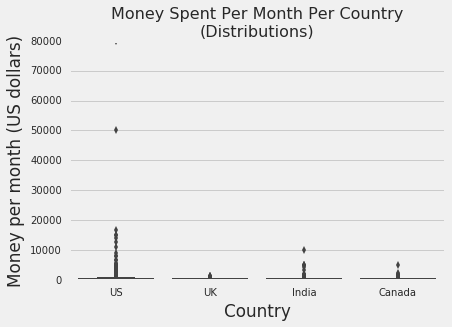

```python
sns.boxplot(y = 'spent_per_month', x = 'CountryLive',
            data = sample_interest)
plt.title('Money Spent Per Month Per Country\n(Distributions)',
         fontsize = 16)
plt.ylabel('Money per month (US dollars)')
plt.xlabel('Country')
plt.xticks(range(4), ['US', 'UK', 'India', 'Canada'])
plt.show()
```

You can see immediately that there's something really off for the US: two persons spend each ore than 50,000. I would not say that it is impossible, but highly unlikely, so I will remove any values higher than 20,000 per month.

```python
sample = sample[sample['spent_per_month'] < 20000]
```

```python
sample[['CountryLive', 'spent_per_month']].groupby(['CountryLive']).mean().loc[['United States of America', 'India', 'United Kingdom', 'Canada']]
```

| CountryLive | spent_per_month |
| --- | --- |
| United States of America | 183.800110 |
| India | 135.100982 |
| United Kingdom | 45.534443 |
| Canada | 113.510961 |

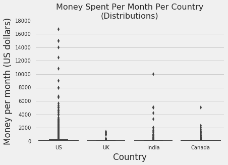

```python
sample_interest = sample[sample['CountryLive'].str.contains('United States of America|India|United Kingdom|Canada')]

sns.boxplot(y = 'spent_per_month', x = 'CountryLive',
            data = sample_interest)
plt.title('Money Spent Per Month Per Country\n(Distributions)',
         fontsize = 16)
plt.ylabel('Money per month (US dollars)')
plt.xlabel('Country')
plt.xticks(range(4), ['US', 'UK', 'India', 'Canada'])
plt.show()
```

We can see a few extreme outliers for India (values over $2500 per month), but it's unclear whether this is good data or not. Maybe these persons attended several bootcamps, which tend to be very expensive.

Let's examine these data points to see if we can find anything relevant.

```python
sample_interest[(sample_interest['CountryLive'] == 'India') &
                (sample_interest['spent_per_month'] >= 2500)]
```

|  | Age | AttendedBootcamp | BootcampFinish | BootcampLoanYesNo | BootcampName | BootcampRecommend | ChildrenNumber | CityPopulation | CodeEventConferences | CodeEventDjangoGirls | CodeEventFCC | CodeEventGameJam | CodeEventGirlDev | CodeEventHackathons | CodeEventMeetup | CodeEventNodeSchool | CodeEventNone | CodeEventOther | CodeEventRailsBridge | CodeEventRailsGirls | CodeEventStartUpWknd | CodeEventWkdBootcamps | CodeEventWomenCode | CodeEventWorkshops | CommuteTime | CountryCitizen | CountryLive | EmploymentField | EmploymentFieldOther | … |
| --- | --- | --- | --- | --- | --- | --- | --- | --- | --- | --- | --- | --- | --- | --- | --- | --- | --- | --- | --- | --- | --- | --- | --- | --- | --- | --- | --- | --- | --- | --- |
| 1728 | 24.0 | 0.0 | NaN | NaN | NaN | NaN | NaN | between 100,000 and 1 million | NaN | NaN | NaN | 1.0 | NaN | NaN | NaN | NaN | NaN | NaN | NaN | NaN | NaN | NaN | NaN | NaN | NaN | India | India | NaN | NaN | … |
| 1755 | 20.0 | 0.0 | NaN | NaN | NaN | NaN | NaN | more than 1 million | NaN | NaN | 1.0 | NaN | NaN | 1.0 | 1.0 | NaN | NaN | NaN | NaN | NaN | NaN | NaN | NaN | NaN | NaN | India | India | NaN | NaN | … |
| 7989 | 28.0 | 0.0 | NaN | NaN | NaN | NaN | NaN | between 100,000 and 1 million | 1.0 | NaN | NaN | NaN | NaN | NaN | NaN | NaN | NaN | NaN | NaN | NaN | NaN | NaN | NaN | 1.0 | 15 to 29 minutes | India | India | software development and IT | NaN | … |
| 8126 | 22.0 | 0.0 | NaN | NaN | NaN | NaN | NaN | more than 1 million | NaN | NaN | NaN | 1.0 | NaN | 1.0 | NaN | NaN | NaN | NaN | NaN | NaN | NaN | NaN | NaN | NaN | NaN | India | India | NaN | NaN | … |
| 13398 | 19.0 | 0.0 | NaN | NaN | NaN | NaN | NaN | more than 1 million | NaN | NaN | NaN | NaN | NaN | NaN | NaN | NaN | 1.0 | NaN | NaN | NaN | NaN | NaN | NaN | NaN | NaN | India | India | NaN | NaN | … |
| 15587 | 27.0 | 0.0 | NaN | NaN | NaN | NaN | NaN | more than 1 million | NaN | NaN | NaN | NaN | NaN | 1.0 | NaN | NaN | NaN | NaN | NaN | NaN | NaN | NaN | NaN | NaN | 15 to 29 minutes | India | India | software development and IT | NaN | … |

It seems that neither participant attended a bootcamp. Overall, it's really hard to figure out from the data whether these persons really spent that much money with learning. The actual question of the survey was "Aside from university tuition, about how much money have you spent on learning to code so far (in US dollars)?", so they might have misunderstood and thought university tuition is included. It seems safer to remove these rows.

```python
sample_interest = sample_interest.drop(sample_interest[(sample_interest['CountryLive'] == 'India') &
                                      (sample_interest['spent_per_month'] >= 2500)].index)
```

```python
sample_interest[(sample_interest['CountryLive'] == 'Canada') &
                (sample_interest['spent_per_month'] > 4500)]
```

|  | Age | AttendedBootcamp | BootcampFinish | BootcampLoanYesNo | BootcampName | BootcampRecommend | ChildrenNumber | CityPopulation | CodeEventConferences | CodeEventDjangoGirls | CodeEventFCC | CodeEventGameJam | CodeEventGirlDev | CodeEventHackathons | CodeEventMeetup | CodeEventNodeSchool | CodeEventNone | CodeEventOther | CodeEventRailsBridge | CodeEventRailsGirls | CodeEventStartUpWknd | CodeEventWkdBootcamps | CodeEventWomenCode | CodeEventWorkshops | CommuteTime | CountryCitizen | CountryLive | EmploymentField | EmploymentFieldOther | … |
| --- | --- | --- | --- | --- | --- | --- | --- | --- | --- | --- | --- | --- | --- | --- | --- | --- | --- | --- | --- | --- | --- | --- | --- | --- | --- | --- | --- | --- | --- | --- |
| 13659 | 24.0 | 1.0 | 0.0 | 0.0 | Bloc.io | 1.0 | NaN | more than 1 million | 1.0 | NaN | 1.0 | NaN | NaN | NaN | 1.0 | NaN | NaN | NaN | NaN | NaN | NaN | NaN | NaN | 1.0 | 30 to 44 minutes | Canada | Canada | finance | NaN | … |

For Canada we can see that person is enrolled to bootcamp and programming only for 2 months. He seems to have paid a large sum of money in the beginning, and then he probably didn't spend anything for the next couple of months after the survey. I'll remove this outlier.

```python
sample_interest = sample_interest.drop(sample_interest[(sample_interest['CountryLive'] == 'Canada') &
                                      (sample_interest['spent_per_month'] > 4500)].index)
```

We can also see more extreme outliers for the US (values over $6000 per month). Let's examine these participants in more detail.

```python
sample_interest[(sample_interest['CountryLive'] == 'United States of America') &
                (sample_interest['spent_per_month'] >= 6000)]
```

|  | Age | AttendedBootcamp | BootcampFinish | BootcampLoanYesNo | BootcampName | BootcampRecommend | ChildrenNumber | CityPopulation | CodeEventConferences | CodeEventDjangoGirls | CodeEventFCC | CodeEventGameJam | CodeEventGirlDev | CodeEventHackathons | CodeEventMeetup | CodeEventNodeSchool | CodeEventNone | CodeEventOther | CodeEventRailsBridge | CodeEventRailsGirls | CodeEventStartUpWknd | CodeEventWkdBootcamps | CodeEventWomenCode | CodeEventWorkshops | CommuteTime | CountryCitizen | CountryLive | EmploymentField | EmploymentFieldOther | … |
| --- | --- | --- | --- | --- | --- | --- | --- | --- | --- | --- | --- | --- | --- | --- | --- | --- | --- | --- | --- | --- | --- | --- | --- | --- | --- | --- | --- | --- | --- | --- |
| 718 | 26.0 | 1.0 | 0.0 | 0.0 | The Coding Boot Camp at UCLA Extension | 1.0 | NaN | more than 1 million | 1.0 | NaN | NaN | NaN | NaN | NaN | NaN | NaN | NaN | NaN | NaN | NaN | NaN | NaN | NaN | NaN | 15 to 29 minutes | United States of America | United States of America | architecture or physical engineering | NaN | … |
| 1222 | 32.0 | 1.0 | 0.0 | 0.0 | The Iron Yard | 1.0 | NaN | between 100,000 and 1 million | NaN | NaN | NaN | NaN | NaN | NaN | 1.0 | NaN | NaN | NaN | NaN | NaN | NaN | NaN | NaN | NaN | NaN | United States of America | United States of America | NaN | NaN | … |
| 3184 | 34.0 | 1.0 | 1.0 | 0.0 | We Can Code IT | 1.0 | NaN | more than 1 million | NaN | NaN | NaN | NaN | NaN | NaN | 1.0 | NaN | NaN | NaN | NaN | NaN | NaN | NaN | NaN | NaN | Less than 15 minutes | NaN | United States of America | software development and IT | NaN | … |
| 3930 | 31.0 | 0.0 | NaN | NaN | NaN | NaN | NaN | between 100,000 and 1 million | NaN | NaN | NaN | NaN | NaN | NaN | NaN | NaN | NaN | NaN | NaN | NaN | NaN | NaN | NaN | NaN | NaN | United States of America | United States of America | NaN | NaN | … |
| 6805 | 46.0 | 1.0 | 1.0 | 1.0 | Sabio.la | 0.0 | NaN | between 100,000 and 1 million | NaN | NaN | NaN | NaN | NaN | NaN | NaN | NaN | NaN | NaN | NaN | NaN | NaN | NaN | NaN | NaN | NaN | United States of America | United States of America | NaN | NaN | … |
| 7198 | 32.0 | 0.0 | NaN | NaN | NaN | NaN | NaN | more than 1 million | 1.0 | NaN | NaN | NaN | NaN | NaN | 1.0 | NaN | NaN | NaN | NaN | NaN | NaN | NaN | NaN | NaN | 15 to 29 minutes | United States of America | United States of America | education | NaN | … |
| 7505 | 26.0 | 1.0 | 0.0 | 1.0 | Codeup | 0.0 | NaN | more than 1 million | NaN | NaN | NaN | NaN | NaN | NaN | NaN | NaN | NaN | NaN | NaN | NaN | 1.0 | NaN | NaN | NaN | NaN | United States of America | United States of America | NaN | NaN | … |
| 9778 | 33.0 | 1.0 | 0.0 | 1.0 | Grand Circus | 1.0 | NaN | between 100,000 and 1 million | NaN | NaN | NaN | NaN | NaN | NaN | 1.0 | NaN | NaN | NaN | NaN | NaN | NaN | NaN | NaN | NaN | 15 to 29 minutes | United States of America | United States of America | education | NaN | … |
| 16650 | 29.0 | 0.0 | NaN | NaN | NaN | NaN | 2.0 | more than 1 million | NaN | NaN | NaN | NaN | NaN | NaN | 1.0 | NaN | NaN | NaN | NaN | NaN | NaN | NaN | NaN | NaN | NaN | United States of America | United States of America | NaN | NaN | … |
| 16997 | 27.0 | 0.0 | NaN | NaN | NaN | NaN | 1.0 | more than 1 million | NaN | NaN | NaN | NaN | NaN | NaN | NaN | NaN | NaN | NaN | NaN | NaN | NaN | NaN | NaN | NaN | 15 to 29 minutes | United States of America | United States of America | health care | NaN | … |
| 17231 | 50.0 | 0.0 | NaN | NaN | NaN | NaN | 2.0 | less than 100,000 | NaN | NaN | NaN | NaN | NaN | NaN | NaN | NaN | NaN | NaN | NaN | NaN | NaN | NaN | 1.0 | NaN | NaN | Kenya | United States of America | NaN | NaN | … |

Six people did attended bootcamps, so it is possible that they really spent large sum of money on learning. For the other five, it's hard to figure out from the data where they could have spent that much money on learning. Consequently, I'll remove those rows where participants reported thay they spend $6000 each month, but they have never attended a bootcamp.

```python
# Remove the respondents who didn't attendent a bootcamp
sample_interest = sample_interest.drop(sample_interest[
                                      (sample_interest['CountryLive'] == 'United States of America') &
                                      (sample_interest['spent_per_month'] >= 6000) &
                                      (sample_interest['AttendedBootcamp'] == 0)].index)
```

Also, you can see the data shows that eight respondents had been programming for no more than three months when they completed the survey. It is similar to Canada situation. So, I will also remove them because they probably didn't spend anything for the next couple of months after the survey.

```python
# Remove the respondents that had been programming for less than 3 months
sample_interest = sample_interest.drop(sample_interest[
                                      (sample_interest['CountryLive'] == 'United States of America') &
                                      (sample_interest['spent_per_month'] >= 6000) &
                                      (sample_interest['MonthsProgramming'] <= 3)].index)
```

Let's recompute the mean values and generate the final box plots.

```python
sample_interest[['CountryLive', 'spent_per_month']].groupby('CountryLive').mean().loc[['United States of America', 'India', 'United Kingdom', 'Canada']]
```

| CountryLive | spent_per_month |
| --- | --- |
| United States of America | 142.654608 |
| India | 65.758763 |
| United Kingdom | 45.534443 |
| Canada | 93.065400 |

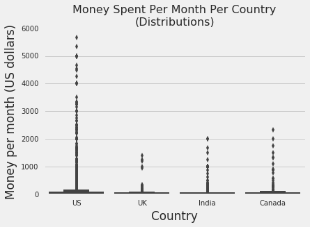

```python
sns.boxplot(y = 'spent_per_month', x = 'CountryLive',
            data = sample_interest)
plt.title('Money Spent Per Month Per Country\n(Distributions)',
         fontsize = 16)
plt.ylabel('Money per month (US dollars)')
plt.xlabel('Country')
plt.xticks(range(4), ['US', 'UK', 'India', 'Canada'])
plt.show()
```

### Choosing the Two Best Markets

Considering the results we've found so far, one country we should definitely advertise in is the US. There are a lot of new coders living there and they are willing to pay a good amount of money each month. As data say americans spend roughly $143 per month, and we sell subscriptions at a price of 59 dollars per month. So, that is a good choice.

For the second market, I would say that UK is indeed not what we are looking for, as they spend only $45 per month. So, we have India and Canada left. Besides the price, second important criteria is the number of potential customers in the country. Let's take a look at it.

```python
frec_table = sample_interest['CountryLive'].value_counts().to_frame()
frec_table['percentage'] = (frec_table['CountryLive'] / frec_table['CountryLive'].sum())*100
frec_table = frec_table.rename(columns={'CountryLive':'Count'}, index={'United States of America': 'USA', 'United Kingdom':'UK'})
frec_table
```

|  | Count | percentage |
| --- | --- | --- |
| USA | 2920 | 74.967908 |
| India | 457 | 11.732991 |
| UK | 279 | 7.163030 |
| Canada | 239 | 6.136072 |

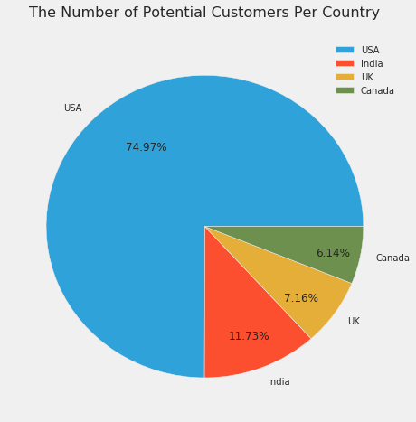

```python
frec_table.plot.pie(y='percentage', figsize=(7, 7))
plt.title('The Number of Potential Customers Per Country\n',fontsize = 16)
plt.ylabel('')

plt.text(-0.5, 0.5, str(round(frec_table['percentage'][0],2))+'%', fontsize=12) # USA
plt.text(0.15, -0.75, str(round(frec_table['percentage'][1],2))+'%', fontsize=12) # India
plt.text(0.5, -0.5, str(round(frec_table['percentage'][2],2))+'%', fontsize=12) # UK
plt.text(0.7, -0.2, str(round(frec_table['percentage'][3],2))+'%', fontsize=12) # Canada

plt.show()
```

Based on data we see that India has more amount of potential customers. But canadian tent to spend more money per month on average. So, it is not that clear to choose between India and Canada.

At this point, it seems that we have several options:

1. Advertise in the US, India, and Canada by splitting the advertisement budget in various combinations:
   - 60% for the US, 25% for India, 15% for Canada.
   - 50% for the US, 30% for India, 20% for Canada; etc.
2. Advertise only in the US and India, or the US and Canada. Again, it makes sense to split the advertisement budget unequally. For instance:
   - 70% for the US, and 30% for India.
   - 65% for the US, and 35% for Canada; etc.
3. Advertise only in the US.

At this point, it's probably best to send our analysis to the marketing team and let them use their domain knowledge to decide. They might want to do some extra surveys in India and Canada and then get back to us for analyzing the new survey data.

## Conclusion

In this project, I analyzed survey data from new coders to find the best two markets to advertise in. The conclusion is that the US would be a good market to advertise in.

For the second best market, I would decided to send the results to the marketing team so they can use their domain knowledge to take the best decision based on y report.